# TXT1_Chapter7_Assignment

# TXT1 Chapter 7 Assignment

# The purpose of this assignment is to use descriptive statistics, data visualizations, and compute the appropriate test statistics for each comparison being made. Here, we are looking at the effects of marital status and sex on tech use to see if there is a statistically significant difference among the groups and if the interaction between sex and marital status has a combined effect on tech use.

# 04/03/2025

# Data: gss2018.rda in the assignment file

```r
# load the necessary libraries
library(tidyverse)
library(car)
```

### Question 1

```r
load("gss2018.rda")

gss.2018 <- GSS

rm(GSS)
```

### Question 2

```r
gss.2018.cleaned <- gss.2018 %>%
  select(SEX, USETECH, MARITAL) %>%
  mutate(
    USETECH = na_if(USETECH, -1),
    USETECH = na_if(USETECH, 999),
    USETECH = na_if(USETECH, 998),
    MARITAL = na_if(MARITAL, 9),
    SEX = factor(SEX, levels=c(1,2), labels=c("male", "female")),
    MARITAL = factor(MARITAL, levels=c(1,2,3,4,5), labels=c("Married","Widowed","Divorced","Separated","Never Married"))
  )
```

### Question 3

```r
# descriptive statistics for USETECH

usetech_stats <- gss.2018.cleaned %>%
  filter(!is.na(USETECH)) %>%
  summarise(USETECH_mean = mean(USETECH),
            USETECH_sd = sd(USETECH))

usetech_stats
```

| USETECH_mean | USETECH_sd |
| --- | --- |
| 55.14762 | 37.83053 |

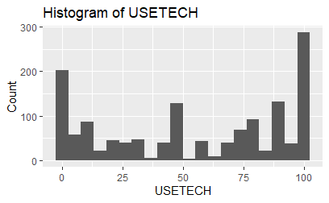

```r
# histogram of USETECH

ggplot(gss.2018.cleaned, aes(x=USETECH)) +
  geom_histogram(bins=20) +
  labs(
    title = "Histogram of USETECH",
    x = "USETECH",
    y = "Count"
  )
```

```r
# descriptive statistics of USETECH by SEX

USETECH_by_SEX_stats <- gss.2018.cleaned %>%
  filter(!is.na(USETECH)) %>%
  group_by(SEX) %>%
  summarise(USETECH_by_SEX_mean = mean(USETECH),
            USETECH_by_SEX_sd = sd(USETECH))

USETECH_by_SEX_stats
```

| SEX | USETECH_by_SEX_mean | USETECH_by_SEX_sd |
| --- | --- | --- |
| male | 50.75628 | 38.28006 |
| female | 59.20902 | 36.97418 |

```r
NA
```

```r
# descriptive statistics of USETECH by MARITAL

USETECH_by_MARITAL_stats <- gss.2018.cleaned %>%
  filter(!is.na(USETECH)) %>%
  group_by(MARITAL) %>%
  summarise(USETECH_by_MARITAL_mean = mean(USETECH),
            USETECH_by_MARITAL_sd = sd(USETECH))

USETECH_by_MARITAL_stats
```

| MARITAL | USETECH_by_MARITAL_mean | USETECH_by_MARITAL_sd |
| --- | --- | --- |
| Married | 59.35127 | 36.49864 |
| Widowed | 48.92453 | 39.48654 |
| Divorced | 51.00615 | 37.58410 |
| Separated | 56.13333 | 40.45401 |
| Never Married | 52.01954 | 38.89093 |

```r
USETECH_by_SEX_MARITAL_stats <- gss.2018.cleaned %>%
  filter(!is.na(USETECH)) %>%
  group_by(SEX, MARITAL) %>%
  summarise(USETECH_by_SEX_MARITAL_mean = mean(USETECH),
            USETECH_by_SEX_MARITAL_sd = sd(USETECH))
USETECH_by_SEX_MARITAL_stats
```

| SEX | MARITAL | USETECH_by_SEX_MARITAL_mean | USETECH_by_SEX_MARITAL_sd |
| --- | --- | --- | --- |
| male | Married | 53.20032 | 37.85674 |
| male | Widowed | 44.00000 | 39.28831 |
| male | Divorced | 48.40526 | 37.12882 |
| male | Separated | 57.09524 | 40.30745 |
| male | Never Married | 48.20961 | 39.10150 |
| female | Married | 65.54127 | 34.03136 |
| female | Widowed | 50.86842 | 39.91895 |
| female | Divorced | 52.66443 | 37.90254 |
| female | Separated | 55.29167 | 41.42933 |
| female | Never Married | 56.25485 | 38.30636 |

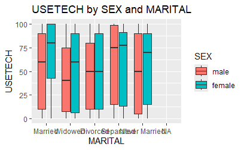

### Question 4

#### Based on the interpretation of the above graph, when comparing tech use across groups by marital status, it would be expected that Separated group would show a higher average tech use than the other groups. For the divorced and separated groups, the average tech use between males and females is about the same, but in the married, widowed, and never married groups, females will show a higher average tech use than the males within those groups. To determine whether or not this interpretation is accurate or statistically significant, further tests will be needed.

### Question 5

```r
anova_USETECH_MARITAL
```

```
    One-way analysis of means

data:  USETECH and MARITAL
F = 3.822, num df = 4, denom df = 1404, p-value = 0.004273
```

#### Interpretation: The F-statistic is significant with a p-value of 0.004273, so a post hoc test is needed to determine which means are statistically significantly different from each other.

```r
USETECH_MARITAL_pairwise_test
```

```
    Pairwise comparisons using t tests with pooled SD

data:  gss.2018.cleaned$USETECH and gss.2018.cleaned$MARITAL

              Married Widowed Divorced Separated
Widowed       0.532   -       -        -
Divorced      0.034   1.000   -        -
Separated     1.000   1.000   1.000    -
Never Married 0.018   1.000   1.000    1.000

P value adjustment method: bonferroni
```

#### Interpretation: There is no statistically significant difference among the Widowed or Separated groups compared to the Married group. However, the Divorced and Never Married groups do show a significant difference in comparison to the Married group in the USETECH category. All of the other comparisons were not statistically significant.

### Question 6

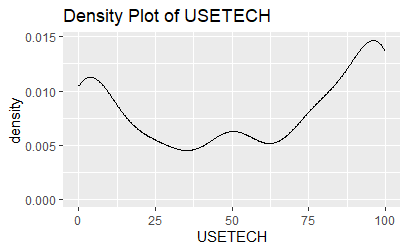

```r
leveneTest_results
```

```
Levene's Test for Homogeneity of Variance (center = median)
        Df F value  Pr(>F)
group    4  2.1587 0.07149 .
      1404
---
Signif. codes:  0 ‘***’ 0.001 ‘**’ 0.01 ‘*’ 0.05 ‘.’ 0.1 ‘ ’ 1
```

#### Interpretation: The data does have equal variance across marital groups, but the data is not normally distributed. Therefore, we need to choose an alternate test.

```r
kruskal_test_results
```

```
    Kruskal-Wallis rank sum test

data:  USETECH by MARITAL
Kruskal-Wallis chi-squared = 12.881, df = 4, p-value = 0.01187
```

#### Interpretation: The p-value is significant, so we can reject the null hypothesis and conclude that there is a statistically significant difference among the MARITAL groups in terms of tech use.

### Question 7

```r
summary(two_way_results)
```

```
              Df  Sum Sq Mean Sq F value   Pr(>F)
SEX            1   25129   25129  17.931 2.44e-05 ***
MARITAL        4   24732    6183   4.412  0.00151 **
SEX:MARITAL    4    4522    1131   0.807  0.52084
Residuals   1399 1960674    1401
---
Signif. codes:  0 ‘***’ 0.001 ‘**’ 0.01 ‘*’ 0.05 ‘.’ 0.1 ‘ ’ 1
936 observations deleted due to missingness
```

#### Interpretation: Based on these results, USETECH differs statistically significantly between SEX and MARITAL groups individually. However, the SEX:MARITAL comparison shows a non-significant p-value. Therefore, we can conclude that the interaction between sex and marital status does not contribute significantly to the difference in tech use, and we fail to reject the null hypothesis.

```r
shapiro_test_results
```

```
    Shapiro-Wilk normality test

data:  two_way_results$residuals
W = 0.90534, p-value < 2.2e-16
```

```r
levene_results
```

```
Levene's Test for Homogeneity of Variance (center = median)
        Df F value  Pr(>F)
group    9  2.8823 0.00223 **
      1399
---
Signif. codes:
  0 ‘***’ 0.001 ‘**’ 0.01 ‘*’ 0.05 ‘.’
  0.1 ‘ ’ 1
```

#### Interpretation: The p-value for both tests is significant, so the data does not meet the assumptions of normality or equal variances for a two-way ANOVA test.